# Solutions to Exercises of Introduction to Statistical Learning, Chapter 8

Guillermo Martinez Dibene

7th of May, 2021

This chapter is all about trees: decision trees, bootstrapping aggregating (bagging), random forests and boosting.

### Decision trees

Basically, a decision tree with $J$ leafs is
$$\hat{Y}_i = \sum_{j = 1}^J c_j \mathbf{1}_{\{X_i \in \mathrm{R}_j\}}$$
where each $c_j$ will correspond to:

1. The *mean* of the $X_i \in \mathrm{R}_j$ in the case of regression.
2. The *mode* of the $X_i \in \mathrm{R}_j$ in the case of classification.

The trees are constructed by *recursive binary splitting*.

### Bagging trees

This is bootstrap for decision trees. Choose a very large $B.$ For $i = 1, \ldots, B,$ we take a sample with replacement from the original features and produce a decision tree $\hat{f}_i$. Then, we take a simple or weighted average in the case of regression or take a majority or a weighted vote in the case of classification to produce a bagged tree.

### Random forests

This is similar to bagging in the sense that we build a number of single decision trees by sampling with replacement from the original features but this time, when building each tree, instead of using *recursive binary splitting* using the feature that reduces the error or increases the purity the most, we select a random feature to do the splitting. This helps decorrelate the found trees and often provides improvements. Again, we combine all the decision trees by (weighted) averaging or voting on them.

### Boosting

This uses a very large number of trees, each of which contributes a small amount (known as the *learning rate*) and at each step uses decision trees with a single split (called *stumps*), and repeat on the residuals.

1. Start with a zero model $\hat{f} = 0$ and full residuals $r_i = y_i.$
2. For each iteration $b = 1, \ldots, B$:
   - Fit a stump $\hat{f}_b$ using the features $X$ and response $r.$
   - Update the model by $\hat{f} \leftarrow \hat{f} + \lambda \hat{f}_b.$
   - Update the residuals $r_i \leftarrow r_i - \lambda \hat{f}_b (x_i).$
3. Return $\hat{f},$ which equals $\lambda \sum\limits_{b = 1}^B \hat{f}_b.$+

# Exercise 7

In this exercise we continue an example from the book. We use the `Boston` data set and we will plot the error for a grid of values.

```r
boston <- as_tibble(Boston)
#This data set has about 500 observations. To estimate the MSE we will do 5-CV
k <- 5
folds <- sample(1:k, size = nrow(boston), replace = TRUE)

#We are going to do a grid with
num_trees <- c(200, 350, 500, 750, 1000)
num_feat  <- c(2, 4, 5, 6, 8)

#We create an array where we will do the estimations
cv_boston <- array(NA,
    dim = c(k, length(num_feat), length(num_trees)),
    dimnames = list(1:k, num_feat, num_trees)
)

#For each fold
for (p in 1:k) {
    #For each number of features to select from
    for (q in seq_along(num_feat)) {
        #For each number of trees
        for (t in seq_along(num_trees)) {
            #Fit a model with the appropriate parameters using all the observations but the testing ones
            temp_model <- randomForest(
                medv ~ .,
                data = boston[folds != p, ],
                mtry = num_feat[[q]],
                ntree = num_trees[[t]])
            temp_pred <- predict(
                temp_model,
                newdata = boston[folds == p, ])
            cv_boston[p, q, t] <- mean( (boston$medv[folds == p] - temp_pred)^2 )
        }
    }
}
cv_boston_means <- apply(cv_boston, c(2,3), mean)
```

```r
cv_boston_means
```

```
##        200      350      500      750     1000
## 2 12.85480 12.60985 12.86604 13.01414 12.98609
## 4 10.58896 10.48256 10.53512 10.54937 10.56798
## 5 10.32367 10.21384 10.30007 10.25914 10.09438
## 6 10.16941 10.27223 10.26684 10.19307 10.13266
## 8 10.08195 10.25759 10.10376 10.03571 10.07528
```

We can see that letting the parameters `mtry` equal to 8 features to choose from per tree and fitting `ntree = 750` trees give the best results.

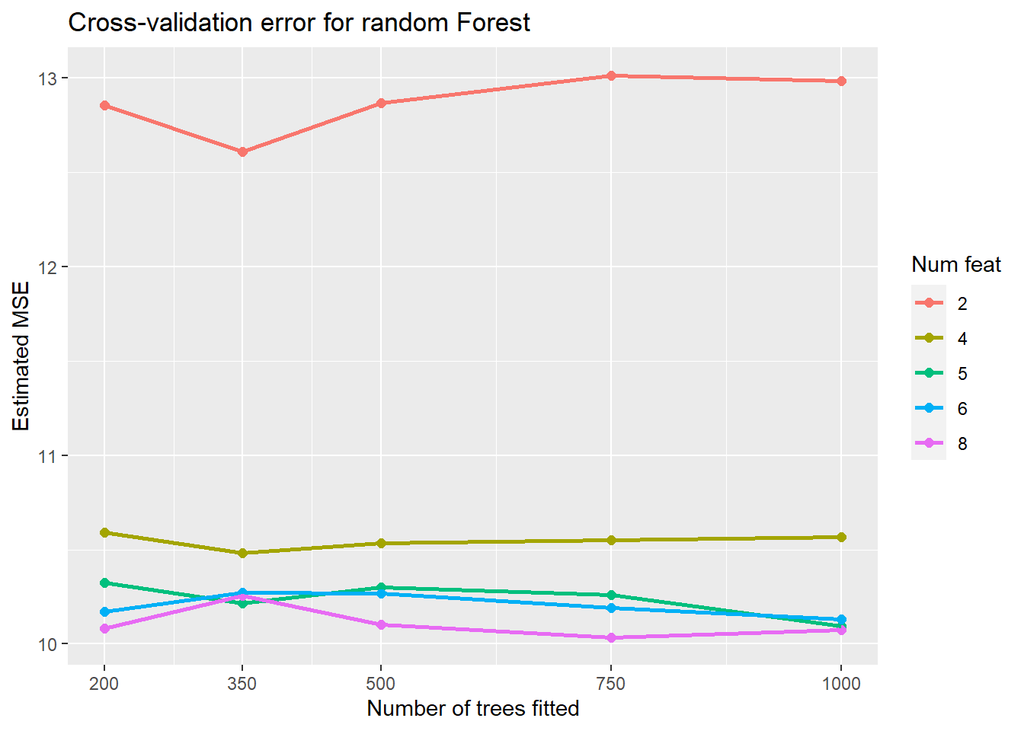

```r
cv_boston_means <- as_tibble(cv_boston_means) %>%
    mutate(
        m = num_feat,
        m = as_factor(m),
    ) %>%
    pivot_longer(cols = 1:length(num_trees), names_to = "num_trees", values_to = "est_MSE") %>%
    mutate(
        num_trees = as.numeric(num_trees)
    )
cv_boston_means %>% ggplot(aes(num_trees, est_MSE, colour = m)) +
    geom_point(size = 2) +
    geom_line(size = 1) +
    labs(
        title = "Cross-validation error for random Forest",
        x = "Number of trees fitted",
        y = "Estimated MSE",
        colour = "Num feat"
    ) +
    scale_x_continuous(breaks = num_trees)
```

The previous graph also tells that using $\left\lceil \sqrt{p} \right\rceil = 4$ was not enough and we needed 5-8 features. Also, the number of trees does not seem to be important since the entire range performed more or less the same. Thus, using 5 features with 200 trees seems to be best.

```r
boston_final_tree <- randomForest(medv ~ ., data = Boston, mtry = 5, ntrees = 200)
boston_final_pred <- predict(boston_final_tree, newdata = Boston)
boston_medv_mean <- mean(Boston$medv)
boston_r2 <- 1 - mean( (Boston$medv - boston_final_pred)^2 ) / mean( (Boston$medv - boston_medv_mean)^2 )
boston_r2
```

```
## [1] 0.9778685
```

# Exercise 8

We will now try to do a regression on the `Carseat` data set using trees. This data set contains the variable `Sales` which is what we will try to predict here. It is the number of units of sales in the thousands.

```r
set.seed(7)
train = sample(1:nrow(Carseats), size = 0.8*nrow(Carseats))
carseat_train <- as_tibble(Carseats[train, ])
carseat_test  <- as_tibble(Carseats[-train,])
```

We are going to also optimise a random forest for this data set, this time, however, we have a test set.

```r
dim(carseat_train)
```

```
## [1] 320  11
```

Since this is a rather small number of observations, we will do a simple 4-fold cross validation. The number of features in this data set is 10, so we can try 3-6 features for the random forest.

```r
k <- 4
folds <- sample(1:k, size = nrow(carseat_train), replace = TRUE)

num_trees <- c(100, 200, 350, 500, 750, 1000)
num_feat  <- 3:6

cv_carseats <- array(NA, dim = c(k, length(num_feat), length(num_trees)), dimnames = list(paste(1:k), num_feat, num_trees))

for (i in 1:k) {
    for (p in seq_along(num_feat)) {
        for (t in seq_along(num_trees)) {
            temp_model <- randomForest(
                Sales ~ .,
                data = carseat_train[folds != i, ],
                mtry = p,
                ntree = t
            )
            temp_pred <- predict(temp_model, newdata = carseat_train[folds == i, ])
            cv_carseats[i, p, t] <- mean( (carseat_train$Sales[folds == i] - temp_pred)^2 )
        }
    }
}

cv_carseats_mean <- apply(cv_carseats, c(2,3), mean)
```

The cross-validates MSE are

```r
cv_carseats_mean
```

```
##        100      200      350      500      750     1000
## 3 9.392190 7.515933 5.802923 6.015034 5.481311 6.196736
## 4 7.487439 6.988503 5.104683 4.749939 4.879773 4.489850
## 5 8.216106 5.783423 4.356466 4.004596 3.959031 4.167401
## 6 7.888314 4.348352 4.388522 4.297642 4.105386 3.614129
```

It clearly is the case that the CV selected the corner of our grid. We redo the CV taking this into account. Since the algorithm is slower the higher the number of trees, we can increase them only so much.

```r
num_trees <- c(750, 1000, 1500, 2000)
num_feat  <- 6:8

cv_carseats <- array(NA, dim = c(k, length(num_feat), length(num_trees)), dimnames = list(paste(1:k), num_feat, num_trees))

for (i in 1:k) {
    for (p in seq_along(num_feat)) {
        for (t in seq_along(num_trees)) {
            temp_model <- randomForest(
                Sales ~ .,
                data = carseat_train[folds != i, ],
                mtry = p,
                ntree = t
            )
            temp_pred <- predict(temp_model, newdata = carseat_train[folds == i, ])
            cv_carseats[i, p, t] <- mean( (carseat_train$Sales[folds == i] - temp_pred)^2 )
        }
    }
}

cv_carseats_mean <- apply(cv_carseats, c(2,3), mean)
cv_carseats_mean
```

```
##         750     1000     1500     2000
## 6  9.002203 6.790106 5.963729 5.999582
## 7 10.033954 6.024067 6.022872 5.306173
## 8  7.875624 5.614812 4.353886 4.098439
```

Due to the randomness, the estimated MSE went much higher than the original grid. Due to this, we will take a more conservative approach and choose a pair of values where the MSE seem to be the most stable, which would be `mtry = 5` and `ntree = 750`.

```r
carseats_final_tree <- randomForest(Sales ~ ., data = carseat_train, mtry = 5, ntree = 750)
carseats_final_pred <- predict(carseats_final_tree, newdata = carseat_test)
carseats_test_mse <- mean( (carseats_final_pred - carseat_test$Sales)^2 )
carseats_test_mse
```

```
## [1] 1.749056
```

This is a very good MSE, specially considering that this is a *test MSE*, not an estimated one. Finally we calculate the $R^2$ for this model.

```r
carseats_final_pred_train <- predict(carseats_final_tree, newdata = carseat_train)
carseats_sales_mean <- mean(carseat_train$Sales)
carseats_r2 <- 1 - mean( (carseat_train$Sales - carseats_final_pred_train)^2 ) / mean( (carseat_train$Sales - carseats_sales_mean)^2 )
carseats_r2
```

```
## [1] 0.9401641
```

This model explains $94\%$ of the variability in the data. Quite good.

# Exercise 9

```r
k <- 4
folds <- sample(1:k, size = 800, replace = TRUE)

num_feat <- c(3, 4, 6, 10, 15)
num_trees <- c(100, 250, 500, 1000)

cv_oj <- array(NA, dim = c(k, length(num_feat), length(num_trees)), dimnames = list(paste(1:k), num_feat, num_trees))

for (i in 1:k) {
    for (p in seq_along(num_feat)) {
        for (t in seq_along(num_trees)) {
            temp_model <- randomForest(
                Purchase ~ .,
                data = oj_train[folds != i, ],
                mtry = p,
                ntree = t
            )
            temp_pred <- predict(temp_model, newdata = oj_train[folds == i, ])
            cv_oj[i, p, t] <- mean( oj_train$Purchase[folds == i] == temp_pred)
        }
    }
}

cv_oj_mean <- apply(cv_oj, c(2,3), mean)
cv_oj_mean
```

```
##          100       250       500      1000
## 3  0.6947940 0.6732154 0.7162821 0.7171498
## 4  0.6958323 0.7276259 0.7659446 0.7430378
## 6  0.7426288 0.7434596 0.7358070 0.7602303
## 10 0.7307091 0.7146133 0.7618362 0.7667729
## 15 0.7236285 0.7289389 0.7628519 0.7541781
```

```r
oj_final <- randomForest(Purchase ~ ., data = oj_train, mtry = 4, ntree = 250)
oj_final_pred <- predict(oj_final, newdata = oj_test)
oj_final_test_acc <- mean(oj_final_pred == oj_test$Purchase)
oj_final_test_acc
```

```
## [1] 0.8129771
```

This model produce $81.3\%$ accuracy. The confusion matrix is

```r
table(oj_final_pred, oj_test$Purchase)
```

```
##
## oj_final_pred   0   1
##             0 135  35
##             1  14  78
```

Just for comparison, we also apply a logistic regression (which does not require any parameter refinement).

```r
oj_logis <- glm(Purchase ~ ., data = oj_train, family = binomial)
oj_logis_pred <- predict(oj_logis, newdata = oj_test, type = "response")
table(ifelse(oj_logis_pred > 0.5, 1, 0), oj_test$Purchase)
```

```
##
##       0   1
##   0 137  31
##   1  12  82
```

And this very simple model outperforms the random forest classifier, with an accuracy of $83.6\%$.

# Exercise 10

The first part of the exercise asks to perform boosting using different learning rates.

```r
lear_rate <- c(0.0001, 0.0005, 0.001, 0.01, 0.05)
n_ <- length(lear_rate)
hitters_boost <- vector("list", n_)
for (i in 1:n_) {
    #Each entry in hitters_boost will contain a fitted model, a prediction and then the test MSE
    hitters_boost[[i]] <- vector("list", 3)
}

for (i in 1:n_) {
    hitters_boost[[i]][[1]] <- gbm(
        LogSalary ~ . - Salary,
        data = hitters_train,
        n.trees = 5000,
        distribution = "gaussian",
        shrinkage = lear_rate[[i]],
        verbose = FALSE)
    hitters_boost[[i]][[2]] <- predict(hitters_boost[[i]][[1]], newdata = hitters_test)
    hitters_boost[[i]][[3]] <- mean( (hitters_test$LogSalary - hitters_boost[[i]][[2]])^2 )
}
```

```
## Using 5000 trees...
##
## Using 5000 trees...
##
## Using 5000 trees...
##
## Using 5000 trees...
##
## Using 5000 trees...
```

```r
for (i in 1:n_) {
    cat(
        paste(
            "Learning rate:",
            lear_rate[[i]],
            "Test MSE:",
            round(hitters_boost[[i]][[3]], 3),
            "\n"
        )
    )
}
```

```
## Learning rate: 1e-04 Test MSE: 0.433
## Learning rate: 5e-04 Test MSE: 0.252
## Learning rate: 0.001 Test MSE: 0.257
## Learning rate: 0.01 Test MSE: 0.295
## Learning rate: 0.05 Test MSE: 0.331
```

The smallest test MSE came with the learning rate $\lambda = 0.0005$. We cannot transform this MSE back to the `Salary` scale. We can consider the quotient $\sqrt{\mathrm{MSE}} / \mu$ of the square-root of the estimated MSE divided by the mean (this is a unitless quantity - a percentage):

```r
sqrt(hitters_boost[[3]][[3]]) / mean(hitters_test$LogSalary)
```

```
## [1] 0.08649967
```

It is around 9%. Now, in the book, the authors fit a linear model using best subset selection and obtained an MSE of 125,154 (2nd ed, p.250) for the `Salary` response. We do not have exactly the same test set as the authors, but we can use the entire data to have an approximation of the mean of the `Salary` response:

```r
sqrt(125154) / mean(hitters$Salary)
```

```
## [1] 0.660112
```

This is a whopping 66%. That means that, roughly, the boosting tree is much more accurate than the best linear regression model. And since we used only stumps, we have an additive model here as well.

# Exercise 11

In this exercise we will tackle the `Caravan` data set which contains $n = 5822$ observations and $p = 85$ features and a response variable `Purchase` which indicated if the given person bought a caravan (which is a trailer adapted for living).

The first part of the exercise asks to fit a boosting model using 1,000 trees and a learning rate equal to 0.01.

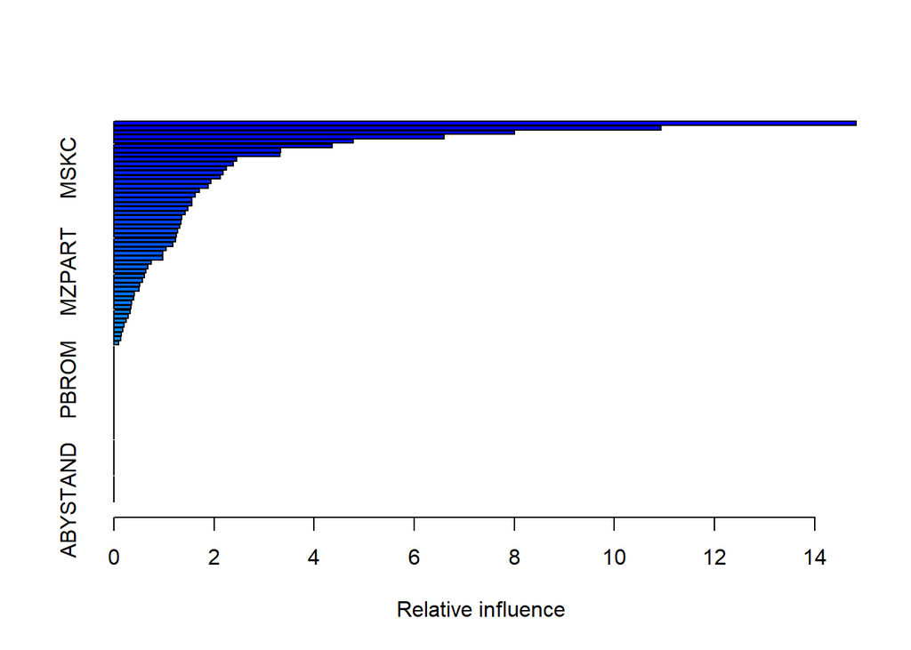

|  | var | rel.inf |
| --- | --- | --- |
| PPERSAUT | PPERSAUT | 14.8261225 |
| APERSAUT | APERSAUT | 10.9245383 |
| MOSTYPE | MOSTYPE | 7.9999536 |
| MOPLMIDD | MOPLMIDD | 6.5904438 |
| MGODOV | MGODOV | 4.7781947 |
| MAUT1 | MAUT1 | 4.3588718 |
| MRELOV | MRELOV | 3.3317343 |
| MBERMIDD | MBERMIDD | 3.3197519 |
| MZFONDS | MZFONDS | 2.4468131 |
| MSKB2 | MSKB2 | 2.3785571 |

[output cut: 75 more lines]

```r
car_boost <- gbm(
    Purchase ~ ., #Predict using all variables
    data = caravan_train,
    distribution = "bernoulli", #This is a binary classification problem
    n.trees = 1000,
    shrinkage = 0.01, #This is the learning rate
    verbose = FALSE
    )
summary(car_boost)
```

The following link has the meaning of this [variables](http://www.liacs.nl/~putten/library/cc2000/data.html)

```r
car_pred <- predict(car_boost, newdata = caravan_test, type = "response")
```

```
## Using 1000 trees...
```

```r
caravan_test <- caravan_test %>%
    mutate(
        pred = ifelse(car_pred > 0.2, 1, 0)
    )
caravan_test %>%
    count(pred, Purchase) %>%
    pivot_wider(names_from = pred, values_from = n)
```

| Purchase | 0 | 1 |
| --- | --- | --- |
| 0 | 4183 | 109 |
| 1 | 266 | 25 |

We see that this data has a precision of $\frac{25}{134} = 18.66\%$, which is not as good as the precision of $26.7\%$ found using KNN with 5 neighbours (Chp. 4, p. 167). However, I suspect there must be a typo in the exercise since in Chapter 4 the authors used 1,000 observations for testing and in this exercise they asked 1,000 observations for training. Generally, the more observation, the better the predictions. I will redo the exercise but now using 1,000 observations for testing.

```r
car_boost2 <- gbm(
    Purchase ~ . - pred,
    data = caravan_test,
    distribution = "bernoulli",
    n.trees = 1000,
    shrinkage = 0.01
)
car_pred2 <- predict(car_boost2, newdata = caravan_train, type = "response")
```

```
## Using 1000 trees...
```

```r
caravan_train2 <- caravan_train %>%
    mutate(
        pred = ifelse(car_pred2 > 0.2, 1, 0)
    )
caravan_train2 %>%
    count(pred, Purchase) %>%
    pivot_wider(names_from = pred, values_from = n)
```

| Purchase | 0 | 1 |
| --- | --- | --- |
| 0 | 913 | 33 |
| 1 | 48 | 6 |

We now get a precision of $\frac{6}{39} = 15.38\%$, which is even worse than before.